# Investigation of indel consensus calling

##Setup

```r
library(tidyverse)
library(ggplot2)
```

# Files and directories

```r
root_dir <- rprojroot::find_root(rprojroot::has_dir(".git"))
db_file <- file.path(root_dir, "scratch", "snv_db.sqlite")
```

### Connect to the database

```r
con <- DBI::dbConnect(RSQLite::SQLite(), db_file)
DBI::dbListTables(con)
```

```
[1] "consensus" "lancet"    "mutect"    "samples"   "strelka"   "vardict"
```

### Set up tables

```r
meta <- tbl(con, "samples")
strelka <- tbl(con, "strelka")
lancet <- tbl(con, "lancet")
mutect <- tbl(con, "mutect")
vardict <- tbl(con, "vardict")
```

### Look at the mutation types

```r
lancet_vars <- count(lancet, Variant_Type, name = 'n_lancet')
mutect_vars <- count(mutect, Variant_Type, name = 'n_mutect')
strelka_vars <- count(strelka, Variant_Type, name = 'n_strelka')

variant_counts <- left_join(lancet_vars, mutect_vars, by = 'Variant_Type') %>%
  left_join(strelka_vars, by = 'Variant_Type') %>%
  as.data.frame()

variant_counts
```

| Variant_Type | n_lancet | n_mutect | n_strelka |
| --- | --- | --- | --- |
| DEL | 245331 | 2011944 | 1741869 |
| DNP | 30736 | 171710 | NA |
| INS | 74750 | 487604 | 980936 |
| ONP | 630 | 70 | NA |
| SNP | 1512547 | 8991219 | 7567215 |
| TNP | 3629 | 9556 | NA |

### Find intersection of all

Note that running the block below does no actual processing, it just sets up the query. Processing will be only be done when we try to look at it.

```r
# Use this so we can make columns back to traditional MAF order after join
full_col_order <- colnames(strelka)

join_cols = c("Chromosome",
              "Start_Position",
              "End_Position",
              "Reference_Allele",
              "Allele",
              "Tumor_Sample_Barcode")

full_consensus <- lancet %>%
  inner_join(mutect,
             by = join_cols,
             suffix = c("s", "l")) %>%
  inner_join(strelka,
             by = join_cols,
             suffix = c("s", "m")) %>%
  select(c(join_cols, 'Variant_Type'))
```

Now let’s look at the variant type breakdown in the consensus. We know that we will be missing the `DNP`, `TNP` and `ONP` classes, but how about the INS and DEL?

```r
consensus_vartypes %>%
  left_join(variant_counts) %>%
  mutate(frac_lancet = n_consensus / n_lancet,
         frac_mutect = n_consensus / n_mutect,
         frac_strelka = n_consensus / n_strelka
         )
```

| Variant_Type | n_consensus | n_lancet | n_mutect | n_strelka | frac_lancet | frac_mutect | frac_strelka |
| --- | --- | --- | --- | --- | --- | --- | --- |
| DEL | 79221 | 245331 | 2011944 | 1741869 | 0.3229148 | 0.03937535 | 0.04548046 |
| INS | 33972 | 74750 | 487604 | 980936 | 0.4544749 | 0.06967129 | 0.03463223 |
| SNP | 1145229 | 1512547 | 8991219 | 7567215 | 0.7571527 | 0.12737194 | 0.15134088 |

So we are keeping only (last check) 45% of lancet insertions and 32% of deletions, compared to 75% of SNPs. That is not terrible, but not great.

## Deletion investigation

Deletions might be called in the same approximate location, but different callers might choose slightly different places to call, making things ambiguous. For example, the change of `CATATAT -> CAT` could be called as a 4 base deletion starting at position 2 or position 4. Do we see evidence of these kinds of ambiguity?

Let’s start by getting all the deletions into “regular” data frames. We will add a column for deletion length, calculated two ways, and reduce the column list to what we need to save space.

```r
wanted_cols <- c(
  "Chromosome",
  "Start_Position",
  "End_Position",
  "Variant_Type",
  "Reference_Allele",
  "Allele",
  "Tumor_Sample_Barcode",
  "t_depth",
  "t_ref_count",
  "t_alt_count")


lancet_dels <- lancet %>%
  filter(Variant_Type == 'DEL')  %>%
  select(wanted_cols) %>%
  as.data.frame() %>%
  mutate(length = End_Position - Start_Position + 1,
         # calculate the length for deletions that don't go to 0
         del_length = stringr::str_length(Reference_Allele) -
                      stringr::str_length(stringr::str_replace(Allele, '-', ''))
         )
mutect_dels <- mutect %>%
  filter(Variant_Type == 'DEL')  %>%
  select(wanted_cols) %>%
  as.data.frame() %>%
  mutate(length = End_Position - Start_Position + 1,
         # calculate the length for deletions that don't go to 0
         del_length = stringr::str_length(Reference_Allele) -
                      stringr::str_length(stringr::str_replace(Allele, '-', ''))
         )

strelka_dels <- strelka %>%
  filter(Variant_Type == 'DEL')  %>%
  select(wanted_cols) %>%
  as.data.frame() %>%
  mutate(length = End_Position - Start_Position + 1,
         # calculate the length for deletions that don't go to 0
         del_length = stringr::str_length(Reference_Allele) -
                      stringr::str_length(stringr::str_replace(Allele, '-', ''))
         )
```

Let’s start by looking at the distribution of deletion lengths for each caller.

```r
caller_lengths <- bind_rows(
  lancet = count(lancet_dels, length),
  mutect = count(mutect_dels, length),
  strelka = count(strelka_dels, length),
  .id = "caller")

caller_del_lengths <- bind_rows(
  lancet = count(lancet_dels, del_length),
  mutect = count(mutect_dels, del_length),
  strelka = count(strelka_dels, del_length),
  .id = "caller")
```

Plot the nominal lengths

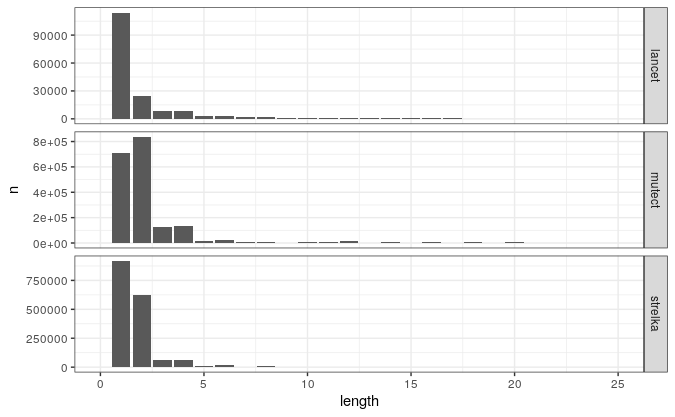

```r
ggplot(caller_lengths, aes(x = length, y = n)) +
  geom_col() +
  facet_grid(rows = 'caller', scales = "free_y") +
  coord_cartesian(xlim = c(0, 25)) +
  theme_bw()
```

Interesting that mutect has more of a propensity for calling even size deletions, but I’m not quite sure what to do with that info…

Plot the actual lengths inferred from alleles…

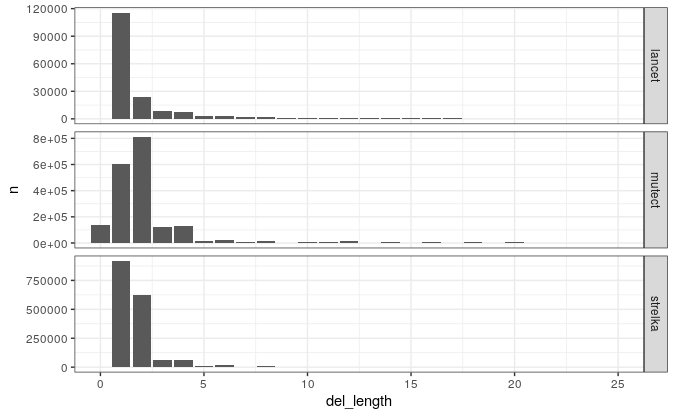

```r
ggplot(caller_del_lengths, aes(x = del_length, y = n)) +
  geom_col() +
  facet_grid(rows = 'caller', scales = "free_y") +
  coord_cartesian(xlim = c(0, 25)) +
  theme_bw()
```

Doesn’t fix mutects problem, though you can see where mutect is calling SNVs as DEL. Odd.

More generally, it does look like the vast majority of the calls are 1-5 bp, so we can probably focus on those, but room for ambiguity among callers still seems high. How can we find places where the “same call” might be missed?